# R Survey Cheat Sheet

David J. Barney[^1]

1/26/2019

# Reading & Exploring Data

To read in your data:

```r
# Comma delimited format
dat <- read.csv("~/your/file/path")
# Tab delimited format
dat <- read.table("~/your/file/path")
# Stata (.dta) format
library(haven)
dat <- read_dta("~/your/file/path")
```

To view observations or summaries of a variable:

```r
# Print the top few observations of a variable
head(dataframe$vector)
# Print the bottom few observations of a variable
tail(dataframe$vector)
# Print all observations of a variable
print(dataframe$vector)
# Access a summary of a variable or model
summary(dataframe$vector)
summary(model)
```

To learn the structure or format of your data:

```r
# Access the type / storage mode of the data
typeof(dataframe$vector)
# Access the structure of the data
str(dataframe)
str(dataframe$vector)
# Access the length of a vector (e.g. the number of observations)
length(dataframe$vector)
# Access the attributes and metadata of an object
attributes(dataframe)
attributes(dataframe$vector)
```

All of the examples in this guide will use the [2016 CCES](https://doi.org/10.7910/DVN/GDF6Z0) loaded in `.dta` format. To replicate,

```r
library(haven)
cces16 <- read_dta("../../Data/2016 CCES/CCES16_Common_OUTPUT_Feb2018_VV.dta")
```

# Manipulating Data

## Recoding Data

To recode values in base R:

```r
#Create a new vector to work with
cces16$ban_ar <- cces16$CC16_330d
#Attitudes toward gun control
#Call all values for "oppose" and replace with zero
cces16$ban_ar[cces16$ban_ar==2] <- 0
#Call all values for skipped / not asked and replace with missing
cces16$ban_ar[cces16$ban_ar==8] <- NA
cces16$ban_ar[cces16$ban_ar==9] <- NA
```

To collapse categories of an ordinal variable in base R:

```r
#Create a new vector to work with
cces16$pid <- cces16$pid7
#Recode values to missing
cces16$pid[cces16$pid==98] <- NA
cces16$pid[cces16$pid==99] <- NA
cces16$pid[cces16$pid==8] <- NA
#Collapse the categories
cces16$pid[cces16$pid==2] <- 1
cces16$pid[cces16$pid==3] <- 1
cces16$pid[cces16$pid==4] <- 2
cces16$pid[cces16$pid==5] <- 3
cces16$pid[cces16$pid==6] <- 3
cces16$pid[cces16$pid==7] <- 3
```

To cut a continuous variable into an ordinal one in base R:

```r
# Create the age variable
cces16$age <- 2016 - cces16$birthyr

cces16$agecats <- cut(cces16$age,
                      breaks=c(-Inf, 35, 50, Inf),
                      labels=c("35 and Under","36 to 50","Over 50"))
```

To flip the direction of coding in base R:

```r
#Flip the coding
cces16$pid_reverse <- 4 - cces16$pid
```

To apply labels to factor levels of a recoded variable:

```r
cces16$pid_reverse <- factor(cces16$pid_reverse,
                             levels = c(1,2,3),
                             labels = c("Republican", "Independent",
                             "Democrat"))
```

## Merging Data

To merge data that have one common vector with the same name:

```r
#Load the supplemental data
cces16s <-  read.csv("../../Data/2016 CCES Supplementary/CC16_Candidates_By_Race.csv")
#Merge the primary and supplemental data by respondent state
cces16c <- merge(cces16, cces16s)
```

```r
#Merge by state with different column names
rm(cces16c)
cces16c <- merge(cces16, cces16s,
                 by.x = "inputstate",
                 by.y = "inputstate")
```

# Descriptive Statistics

## Summary Statistics

To summarize a variable:

```r
summary(cces16$age)
```

```
##    Min. 1st Qu.  Median    Mean 3rd Qu.    Max.
##   18.00   33.00   49.00   47.88   61.00   99.00
```

To call specific summary statistics:

```r
#Mean
mean(cces16$age)
```

```
## [1] 47.88014
```

```r
#Standard deviation
sd(cces16$age)
```

```
## [1] 16.83279
```

```r
#Minimum
min(cces16$age)
```

```
## [1] 18
```

```r
#Maximum
max(cces16$age)
```

```
## [1] 99
```

```r
#Range
range(cces16$age)
```

```
## [1] 18 99
```

```r
#Quantiles
quantile(cces16$age)
```

```
## <Labelled double>
##   0%  25%  50%  75% 100%
##   18   33   49   61   99
##
## Labels:
##  value     label
##   9998   Skipped
##   9999 Not Asked
```

## Tabulations & Cross Tabulations

To tabulate a variable:

```r
# Tabulate PID
prop.table(table(cces16$pid_reverse))
```

```
##
##  Republican Independent    Democrat
##   0.3336641   0.1679444   0.4983915
```

To cross-tabulate two variables:

```r
# Tabulate PID by age categories
pidxage <- table(cces16$pid_reverse, cces16$agecats)
pidxage
```

```
##
##               35 and Under 36 to 50 Over 50
##   Republican          4799     4470   11578
##   Independent         3137     2660    4696
##   Democrat           10427     7059   13653
```

```r
prop.table(pidxage,2)
```

```
##
##               35 and Under  36 to 50   Over 50
##   Republican     0.2613407 0.3150328 0.3868747
##   Independent    0.1708327 0.1874692 0.1569152
##   Democrat       0.5678266 0.4974981 0.4562101
```

## Summary Statistics by Group

To summarize variables by group in base R:

```r
#Create a dataframe of the variables of interest
subgroup_vars <- c("age","pid")
subgroup_matrix <- as.matrix(cces16[subgroup_vars])
subgroup_df <- as.data.frame(subgroup_matrix)
aggregate(subgroup_df$age, list(subgroup_df$pid), mean)
```

```
##   Group.1        x
## 1       1 46.58152
## 2       2 46.97732
## 3       3 51.23725
```

To summarize variables by group with `dplyr`:

```r
library(dplyr)
subgroup_means <- subgroup_df %>%
  group_by(pid) %>%
  summarise(mean = mean(age))
subgroup_means
```

```
## # A tibble: 4 x 2
##     pid  mean
##   <dbl> <dbl>
## 1     1  46.6
## 2     2  47.0
## 3     3  51.2
## 4    NA  38.4
```

To visualize subgroup means with `ggplot`:

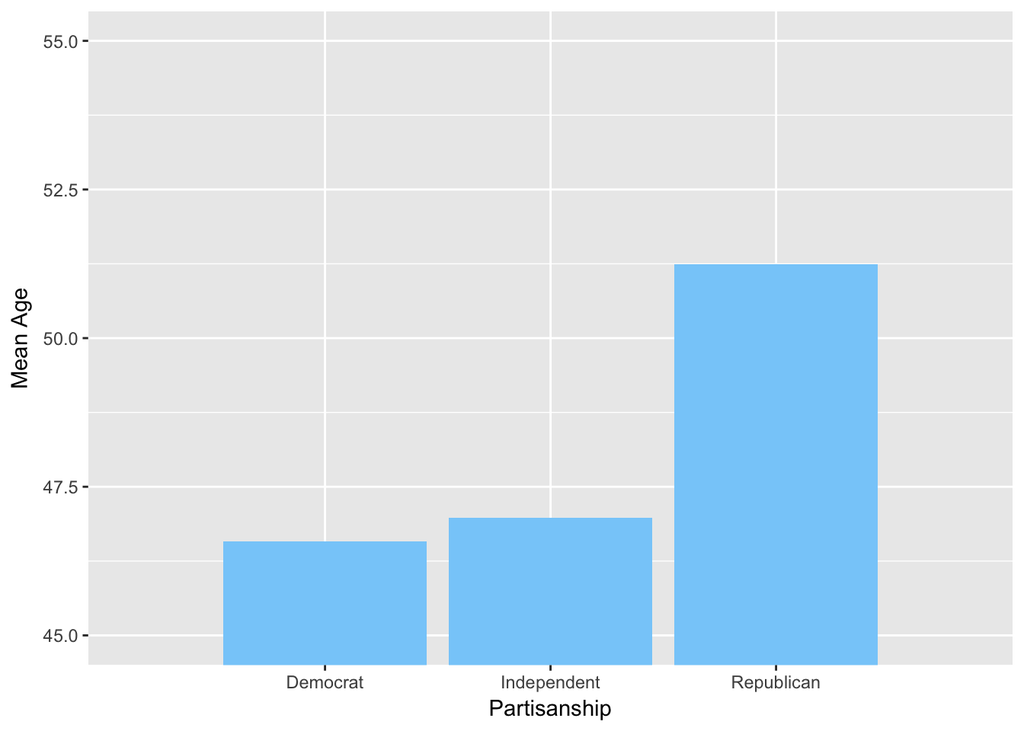

```r
library(ggplot2)
pid_labels <- c("Democrat", "Independent", "Republican")
sg_bp <- ggplot(subgroup_means, aes(y=mean, x=pid)) +
  geom_bar(fill="lightskyblue",stat="identity") +
  #xlab("Partisanship") +
  ylab("Mean Age") +
  scale_x_discrete(name = "Partisanship",
                   limits=pid_labels)
sg_bp <- sg_bp + coord_cartesian(ylim=c(45,55))
sg_bp
```

## Distributions

To plot a histogram of a variable’s distribution using `ggplot2`:

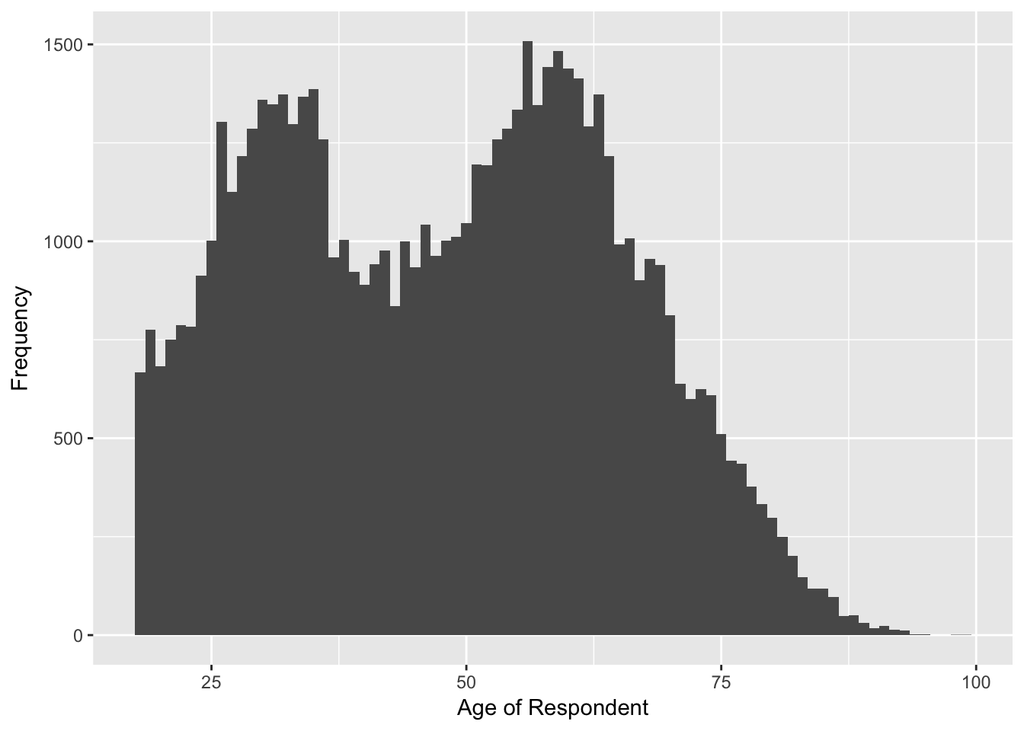

```r
#Histogram for age
library(ggplot2)
age_matrix <- as.matrix(cces16$age)
age_df <- as.data.frame(age_matrix)
ggplot(data = age_df, aes(x=age_df)) +
  geom_histogram(binwidth = 1) +
  xlab("Age of Respondent") +
  ylab("Frequency")
```

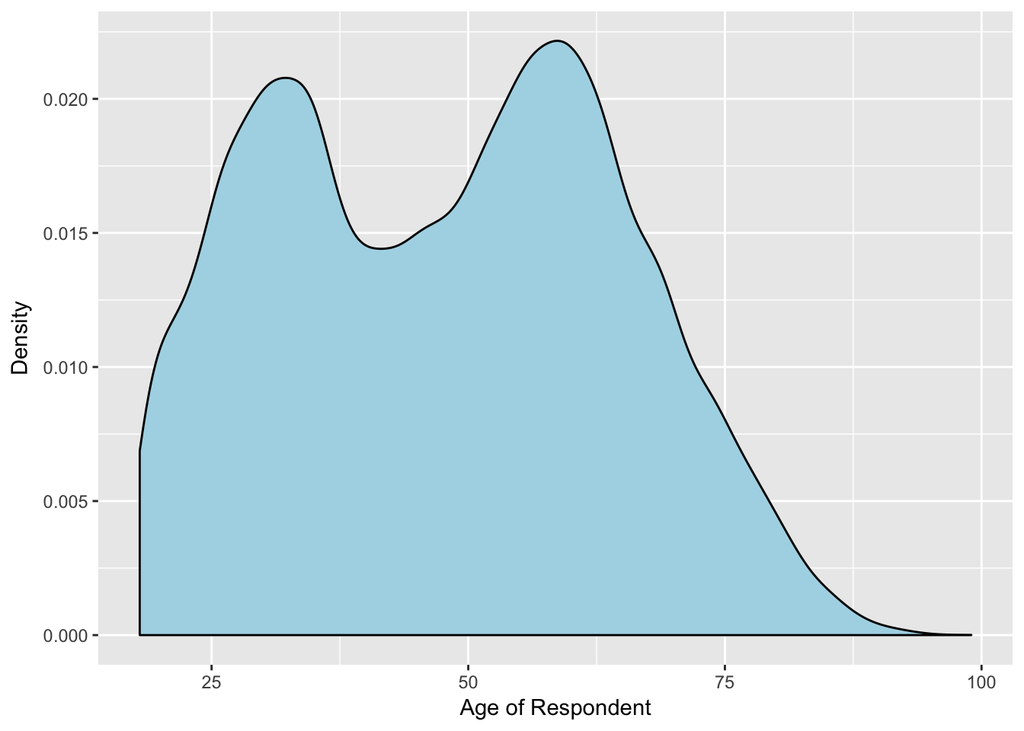

```r
#Density plot
ggplot(data = age_df, aes(x=age_df)) +
  geom_density(fill="lightblue") +
  xlab("Age of Respondent") +
  ylab("Density")
```